# 第11课 回归控制混杂 答案

顶刊研习社

Li Zongzhang

2023-10-29

```r
library(boot)
library(tidyverse)
library(survival)
library(survminer)
library(gt)
library(gtsummary)
```

# 1 习题1

数据文件：load(“lbw.rda”)

[数据文件下载](https://pan.baidu.com/s/13Kv8qLdUs-J0l8FRK5qCvg?pwd=1234)

1.1 将数据集lbw中的变量名全部转换为小写字母，并将数据集lbw复制给对象df，将df中的列id, 列bwt删除.

```r
load("lbw.rda")
names(lbw) <- tolower(names(lbw))
df <- lbw
names(df) <- tolower(names(lbw))
df <- df %>% subset(select = -c(id, bwt))
```

1.2 对df中的变量进行转换：将ptl中等于2或3的组别，都合并到ptl等于1的组别中。将ftv中等于3，4，5，6的组别，都合并到ftv = 2的组别中。将low中等于”BWT <= 2500g”的组别，都转换为1，其余组别转换为0。

```r
df$ptl <- ifelse(df$ptl == 2 | df$ptl == 3, 1, df$ptl) %>%
  as.factor()

df$ftv <- ifelse(df$ftv == 3 | df$ftv == 4 |
                   df$ftv == 5| df$ftv == 6,
                 2,
                 df$ftv) %>%
    as.factor()

df$low <- ifelse(df$low == "BWT <= 2500g", 1, 0)
```

1.3 以table1的形式报告df中各变量的描述性统计。

```r
df %>% tbl_summary()
```

| **Characteristic** | **N = 189**<sup>1</sup> |
| --- | --- |
| low | 59 (31%) |
| age | 23 (19, 26) |
| lwt | 121 (110, 140) |
| race |  |
| white | 96 (51%) |
| black | 26 (14%) |
| other | 67 (35%) |
| smoke | 74 (39%) |
| ptl |  |
| 0 | 159 (84%) |
| 1 | 30 (16%) |
| ht | 12 (6.3%) |
| ui | 28 (15%) |
| ftv |  |
| 0 | 100 (53%) |
| 1 | 47 (25%) |
| 2 | 42 (22%) |

<sup>1</sup> n (%); Median (IQR)

1.4 建立若干个一元logistic回归模型，以low为因变量，age，lwt，race，smoke，ptl，ht，ui，ftv分别为自变量，以表格的形式。报告这些一元logistic回归的估计结果。

```r
df %>%
  gtsummary::tbl_uvregression(
    method = glm,
    y = low,
    method.args = list(family = binomial),
    exponentiate = FALSE
  )
```

| **Characteristic** | **N** | **log(OR)**<sup>1</sup> | **95% CI**<sup>1</sup> | **p-value** |
| --- | --- | --- | --- | --- |
| age | 189 | -0.05 | -0.12, 0.01 | 0.10 |
| lwt | 189 | -0.01 | -0.03, 0.00 | 0.023 |
| race | 189 |  |  |  |
| white |  | — | — |  |
| black |  | 0.84 | -0.08, 1.8 | 0.068 |
| other |  | 0.64 | -0.04, 1.3 | 0.067 |
| smoke | 189 |  |  |  |
| no |  | — | — |  |
| yes |  | 0.70 | 0.08, 1.3 | 0.028 |
| ptl | 189 |  |  |  |
| 0 |  | — | — |  |
| 1 |  | 1.5 | 0.66, 2.3 | <0.001 |
| ht | 189 |  |  |  |
| no |  | — | — |  |
| yes |  | 1.2 | 0.03, 2.5 | 0.046 |
| ui | 189 |  |  |  |
| no |  | — | — |  |
| yes |  | 0.95 | 0.13, 1.8 | 0.023 |
| ftv | 189 |  |  |  |
| 0 |  | — | — |  |
| 1 |  | -0.61 | -1.4, 0.16 | 0.13 |
| 2 |  | -0.34 | -1.2, 0.43 | 0.4 |

<sup>1</sup> OR = Odds Ratio, CI = Confidence Interval

```r
df %>%
  gtsummary::tbl_uvregression(
    method = glm,
    y = low,
    method.args = list(family = binomial),
    exponentiate = TRUE
  )
```

| **Characteristic** | **N** | **OR**<sup>1</sup> | **95% CI**<sup>1</sup> | **p-value** |
| --- | --- | --- | --- | --- |
| age | 189 | 0.95 | 0.89, 1.01 | 0.10 |
| lwt | 189 | 0.99 | 0.97, 1.00 | 0.023 |
| race | 189 |  |  |  |
| white |  | — | — |  |
| black |  | 2.33 | 0.93, 5.77 | 0.068 |
| other |  | 1.89 | 0.96, 3.76 | 0.067 |
| smoke | 189 |  |  |  |
| no |  | — | — |  |
| yes |  | 2.02 | 1.08, 3.80 | 0.028 |
| ptl | 189 |  |  |  |
| 0 |  | — | — |  |
| 1 |  | 4.32 | 1.94, 9.95 | <0.001 |
| ht | 189 |  |  |  |
| no |  | — | — |  |
| yes |  | 3.37 | 1.03, 11.8 | 0.046 |
| ui | 189 |  |  |  |
| no |  | — | — |  |
| yes |  | 2.58 | 1.13, 5.88 | 0.023 |
| ftv | 189 |  |  |  |
| 0 |  | — | — |  |
| 1 |  | 0.54 | 0.24, 1.17 | 0.13 |
| 2 |  | 0.71 | 0.32, 1.53 | 0.4 |

<sup>1</sup> OR = Odds Ratio, CI = Confidence Interval

1.5 报告多元logistic回归模型，模型1的解释变量包括age, lwt, smoke, ui, ptl，ht, ftv; 模型2的解释变量包括age, lwt, smoke, ui, ptl，ht, ftv, 以及race. 对比这两个模型的估计结果，评估在模型1中，是否应该引入race？race是否可以视作模型1中的混杂因素？

```r
model1 <- glm(low ~ age + lwt+ smoke + ui + ptl + ht + ftv,
          df, family = "binomial")


m1 <- tbl_regression(model1,
               exponentiate = TRUE,  #被解释变量odds ratio
               estimate_fun = ~ style_number(.x, digits = 3),
               pvalue_fun = ~ style_pvalue(.x, digits = 3))


model2 <- glm(low ~ age + lwt+ smoke + ui + ptl + ht + ftv + race,
                 df, family = "binomial")

m2 <- tbl_regression(model2,
              exponentiate = TRUE,  #被解释变量odds ratio
              estimate_fun = ~ style_number(.x, digits = 3),
              pvalue_fun = ~ style_pvalue(.x, digits = 3))

tbl_merge(list(m1, m2),
          tab_spanner = c("**Model 1**", "**Model 2**"))
```

| **Characteristic** | **Model 1** **OR**<sup>1</sup> | **Model 1** **95% CI**<sup>1</sup> | **Model 1** **p-value** | **Model 2** **OR**<sup>1</sup> | **Model 2** **95% CI**<sup>1</sup> | **Model 2** **p-value** |
| --- | --- | --- | --- | --- | --- | --- |
| age | 0.954 | 0.884, 1.024 | 0.203 | 0.963 | 0.891, 1.038 | 0.336 |
| lwt | 0.986 | 0.972, 0.998 | 0.031 | 0.984 | 0.970, 0.998 | 0.027 |
| smoke |  |  |  |  |  |  |
| no | — | — |  | — | — |  |
| yes | 1.478 | 0.728, 2.985 | 0.276 | 2.129 | 0.930, 4.975 | 0.075 |
| ui |  |  |  |  |  |  |
| no | — | — |  | — | — |  |
| yes | 1.898 | 0.755, 4.713 | 0.167 | 1.974 | 0.785, 4.914 | 0.143 |
| ptl |  |  |  |  |  |  |
| 0 | — | — |  | — | — |  |
| 1 | 4.262 | 1.712, 11.106 | 0.002 | 3.833 | 1.517, 10.129 | 0.005 |
| ht |  |  |  |  |  |  |
| no | — | — |  | — | — |  |
| yes | 6.861 | 1.767, 30.448 | 0.007 | 6.775 | 1.715, 30.447 | 0.008 |
| ftv |  |  |  |  |  |  |
| 0 | — | — |  | — | — |  |
| 1 | 0.555 | 0.214, 1.354 | 0.207 | 0.646 | 0.244, 1.621 | 0.363 |
| 2 | 1.083 | 0.444, 2.579 | 0.859 | 1.196 | 0.482, 2.920 | 0.695 |
| race |  |  |  |  |  |  |
| white |  |  |  | — | — |  |
| black |  |  |  | 3.295 | 1.154, 9.600 | 0.026 |
| other |  |  |  | 2.097 | 0.855, 5.281 | 0.109 |

<sup>1</sup> OR = Odds Ratio, CI = Confidence Interval

模型2中，raceblack的p值小于0.05，说明raceblack对low有显著影响，应该引入模型1中。race对模型1中的解释变量smoke有影响，对结局low也有影响，race可以视作模型1中smoke的混杂因素。smoke的系数在模型1和模型2中的差距很大，也说明了smoke和race之间的混杂。

# 2 习题2

```r
library(dplyr)
library(forcats)
library(finalfit)
```

2.1 查看数据文件的帮助文档。

```r
?boot::melanoma
library(boot)
data(melanoma)
```

2.2 将melanoma保存为对象df, 在df中追加变量的变量status_os。当status等于2时，代表个体是存活的，令status_os等于0；若status等于1或3，代表个体死于黑色素瘤melanoma，或者死于其他疾病，令status_os等于1。

```r
df <- melanoma %>%
        mutate(status_os = if_else(status == 2, 0, 1))
```

2.3 以table1的形式报告df中各变量的描述性统计。

```r
df %>% tbl_summary()
```

| **Characteristic** | **N = 205**<sup>1</sup> |
| --- | --- |
| time | 2,005 (1,525, 3,042) |
| status |  |
| 1 | 57 (28%) |
| 2 | 134 (65%) |
| 3 | 14 (6.8%) |
| sex | 79 (39%) |
| age | 54 (42, 65) |
| year | 1,970.00 (1,968.00, 1,972.00) |
| thickness | 1.94 (0.97, 3.56) |
| ulcer | 90 (44%) |
| status_os | 71 (35%) |

<sup>1</sup> Median (IQR); n (%)

2.4 建立若干个一元Cox回归模型，以status_os为因变量，age，sex，thickness，ulcer分别为自变量，以表格的形式。报告这些一元logistic回归的估计结果。

```r
df %>%
  gtsummary::tbl_uvregression(
    method = coxph,
    y = Surv(time, status_os),
    exponentiate = FALSE
  )
```

| **Characteristic** | **N** | **log(HR)**<sup>1</sup> | **95% CI**<sup>1</sup> | **p-value** |
| --- | --- | --- | --- | --- |
| status | 205 | -2.2 | -2.7, -1.7 | <0.001 |
| sex | 205 | 0.66 | 0.19, 1.1 | 0.006 |
| age | 205 | 0.03 | 0.01, 0.05 | <0.001 |
| year | 205 | -0.04 | -0.14, 0.05 | 0.4 |
| thickness | 205 | 0.15 | 0.09, 0.21 | <0.001 |
| ulcer | 205 | 1.3 | 0.76, 1.8 | <0.001 |

<sup>1</sup> HR = Hazard Ratio, CI = Confidence Interval

```r
m1 <- coxph(Surv(time, status_os) ~
        sex +  thickness + ulcer, data = df) %>%
  tbl_regression()

m2 <- coxph(Surv(time, status_os) ~
        age + sex +  thickness + ulcer, data = df) %>%
  tbl_regression()

tbl_merge(list(m1, m2),
          tab_spanner = c("**Model 1**", "**Model 2**"))
```

| **Characteristic** | **Model 1** **log(HR)**<sup>1</sup> | **Model 1** **95% CI**<sup>1</sup> | **Model 1** **p-value** | **Model 2** **log(HR)**<sup>1</sup> | **Model 2** **95% CI**<sup>1</sup> | **Model 2** **p-value** |
| --- | --- | --- | --- | --- | --- | --- |
| sex | 0.46 | 0.00, 0.93 | 0.052 | 0.41 | -0.06, 0.88 | 0.085 |
| thickness | 0.11 | 0.04, 0.18 | 0.002 | 0.10 | 0.03, 0.17 | 0.004 |
| ulcer | 0.96 | 0.43, 1.5 | <0.001 | 0.95 | 0.43, 1.5 | <0.001 |
| age |  |  |  | 0.02 | 0.01, 0.04 | 0.005 |

<sup>1</sup> HR = Hazard Ratio, CI = Confidence Interval

# 3 习题3

利用习题2中df数据框中的age, sex, thickness, ulcer, status_os，使用贝叶斯网络学习分析变量之间的关联关系，绘制有向无环图。

```r
library(bnlearn)

dfbn <- df %>% select(age, sex, thickness, ulcer, status_os)


# 必然的路径
Whitelist <- matrix(c("thickness", "status_os",
                      "sex", "status_os"),
                    ncol = 2, byrow = TRUE)
colnames(Whitelist) <- c("from", "to")
Whitelist
```

```
     from        to
[1,] "thickness" "status_os"
[2,] "sex"       "status_os"
```

```r
# 禁止的路径
Blacklist <- matrix(c("thickness", "age",
                      "ulcer", "age",
                      "status_os", "age",
                      "sex", "age",
                      "age", "sex",
                      "ulcer", "sex",
                      "status_os", "sex",
                      "thickness", "sex"),
                    ncol = 2, byrow = TRUE)
colnames(Blacklist) <- c("from", "to")
Blacklist
```

```
     from        to
[1,] "thickness" "age"
[2,] "ulcer"     "age"
[3,] "status_os" "age"
[4,] "sex"       "age"
[5,] "age"       "sex"
[6,] "ulcer"     "sex"
[7,] "status_os" "sex"
[8,] "thickness" "sex"
```

```r
Res <- pc.stable(dfbn,
                 whitelist = Whitelist,
                 blacklist = Blacklist)
Res
```

```
  Bayesian network learned via Constraint-based methods

  model:
   [age][sex][ulcer][thickness|age:ulcer][status_os|age:sex:thickness:ulcer]
  nodes:                                 5
  arcs:                                  6
    undirected arcs:                     0
    directed arcs:                       6
  average markov blanket size:           4.00
  average neighbourhood size:            2.40
  average branching factor:              1.20

  learning algorithm:                    PC (Stable)
  conditional independence test:         Pearson's Correlation
  alpha threshold:                       0.05
  tests used in the learning procedure:  40
```

```r
fit <- bn.fit(Res, dfbn)
fit
```

```
  Bayesian network parameters

  Parameters of node age (Gaussian distribution)

Conditional density: age
Coefficients:
(Intercept)
   52.46341
Standard deviation of the residuals: 16.67171

  Parameters of node sex (Gaussian distribution)

Conditional density: sex
Coefficients:
(Intercept)
  0.3853659
Standard deviation of the residuals: 0.487873

  Parameters of node thickness (Gaussian distribution)

Conditional density: thickness | age + ulcer
Coefficients:
(Intercept)          age        ulcer
 0.36009836   0.02867503   2.40388736
Standard deviation of the residuals: 2.650332

  Parameters of node ulcer (Gaussian distribution)

Conditional density: ulcer
Coefficients:
(Intercept)
  0.4390244
Standard deviation of the residuals: 0.4974829

  Parameters of node status_os (Gaussian distribution)

Conditional density: status_os | age + sex + thickness + ulcer
Coefficients:
 (Intercept)           age           sex     thickness         ulcer
-0.067552952   0.003727269   0.099343164   0.026401964   0.234556020
Standard deviation of the residuals: 0.4358262
```

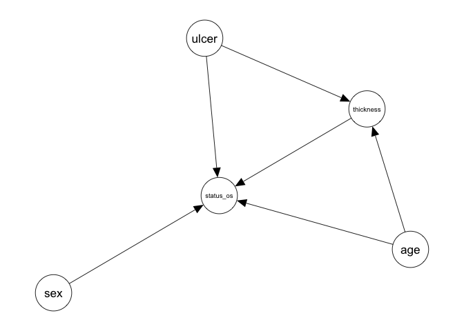

```r
library(qgraph)
g <- qgraph(Res, legend.cex = 0.5,
            asize = 5, edge.color = "black")
```

```r
boot <- boot.strength(dfbn,
                      R = 1000,
                      algorithm = "pc.stable",
                      algorithm.args = list(whitelist = Whitelist,
                                            blacklist = Blacklist)
)
boot
```

```
        from        to strength direction
1        age       sex    0.000 0.0000000
2        age thickness    0.529 1.0000000
3        age     ulcer    0.028 1.0000000
4        age status_os    0.444 1.0000000
5        sex       age    0.000 0.0000000
6        sex thickness    0.317 1.0000000
7        sex     ulcer    0.161 1.0000000
8        sex status_os    1.000 0.9760000
9  thickness       age    0.529 0.0000000
10 thickness       sex    0.317 0.0000000
11 thickness     ulcer    0.996 0.4176707
12 thickness status_os    1.000 0.9395000
13     ulcer       age    0.028 0.0000000
14     ulcer       sex    0.161 0.0000000
15     ulcer thickness    0.996 0.5823293
16     ulcer status_os    0.910 0.8335165
17 status_os       age    0.444 0.0000000
18 status_os       sex    1.000 0.0240000
19 status_os thickness    1.000 0.0605000
20 status_os     ulcer    0.910 0.1664835
```

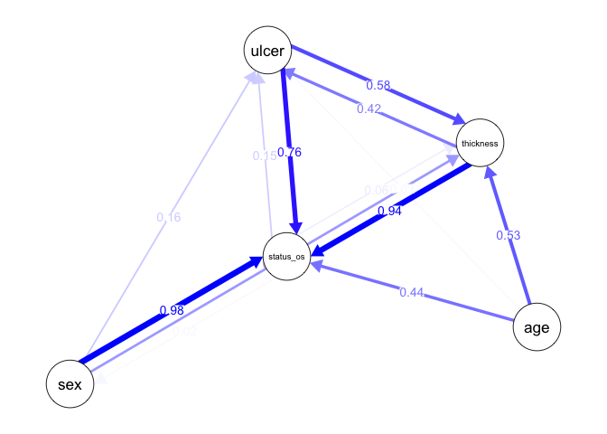

```r
qgraph(boot,
       legend.cex = 0.5,
       edge.labels = TRUE, layout = g$layout,
       asize = 5, edge.color = "blue")
```